# Data Analysis with R - Prosper Loan

# Univariate Plots Section

This dataset contains the loan data for Prosper customers from 2005 to 2014. Prosper is a company based in San Francisco, California. Their website, Prosper.com, provides a marketplace for peer-to-peer lending. Both lender and borrow can use the website to invest or borrow money. The loan examined in this dataset is best described as an annuity. The loan principle balance is provided by the lender to the borrower at the beginning of the loan. Over the term of the loan, the borrower pays a fixed monthly payment that includes a portion of principle and interest. If all monthly payments are made, the loan is paid off at the end of its term. Prosper performs all screening, initial credit checks, and collection of the loan in exchange for a 1% fee on each loan payment.

Overall, this Prosper dataset has 113937 objects with 82 variables. The variables provide information regarding the loan, the borrower, and the Prosper ratings. The data can be numeric, date, integer, range, or factors. To perform trend analysis, I’ve extracted the year in Listing Creation Date to create the Listing Creation Year variable.

```
## 'data.frame':    113937 obs. of  82 variables:
##  $ ListingKey                         : Factor w/ 113066 levels "00003546482094282EF90E5",..: 7180 7193 6647 6669 6686 6689 6699 6706 6687 6687 ...
##  $ ListingNumber                      : int  193129 1209647 81716 658116 909464 1074836 750899 768193 1023355 1023355 ...
##  $ ListingCreationDate                : Factor w/ 113064 levels "2005-11-09 20:44:28.847000000",..: 14184 111894 6429 64760 85967 100310 72556 74019 97834 97834 ...
##  $ CreditGrade                        : Factor w/ 9 levels "","A","AA","B",..: 5 1 8 1 1 1 1 1 1 1 ...
##  $ Term                               : int  36 36 36 36 36 60 36 36 36 36 ...
##  $ LoanStatus                         : Factor w/ 12 levels "Cancelled","Chargedoff",..: 3 4 3 4 4 4 4 4 4 4 ...
##  $ ClosedDate                         : Factor w/ 2803 levels "","2005-11-25 00:00:00",..: 1138 1 1263 1 1 1 1 1 1 1 ...
##  $ BorrowerAPR                        : num  0.165 0.12 0.283 0.125 0.246 ...
##  $ BorrowerRate                       : num  0.158 0.092 0.275 0.0974 0.2085 ...
##  $ LenderYield                        : num  0.138 0.082 0.24 0.0874 0.1985 ...
##  $ EstimatedEffectiveYield            : num  NA 0.0796 NA 0.0849 0.1832 ...
##  $ EstimatedLoss                      : num  NA 0.0249 NA 0.0249 0.0925 ...
##  $ EstimatedReturn                    : num  NA 0.0547 NA 0.06 0.0907 ...
##  $ ProsperRating..numeric.            : int  NA 6 NA 6 3 5 2 4 7 7 ...
```

[output cut: 68 more lines]

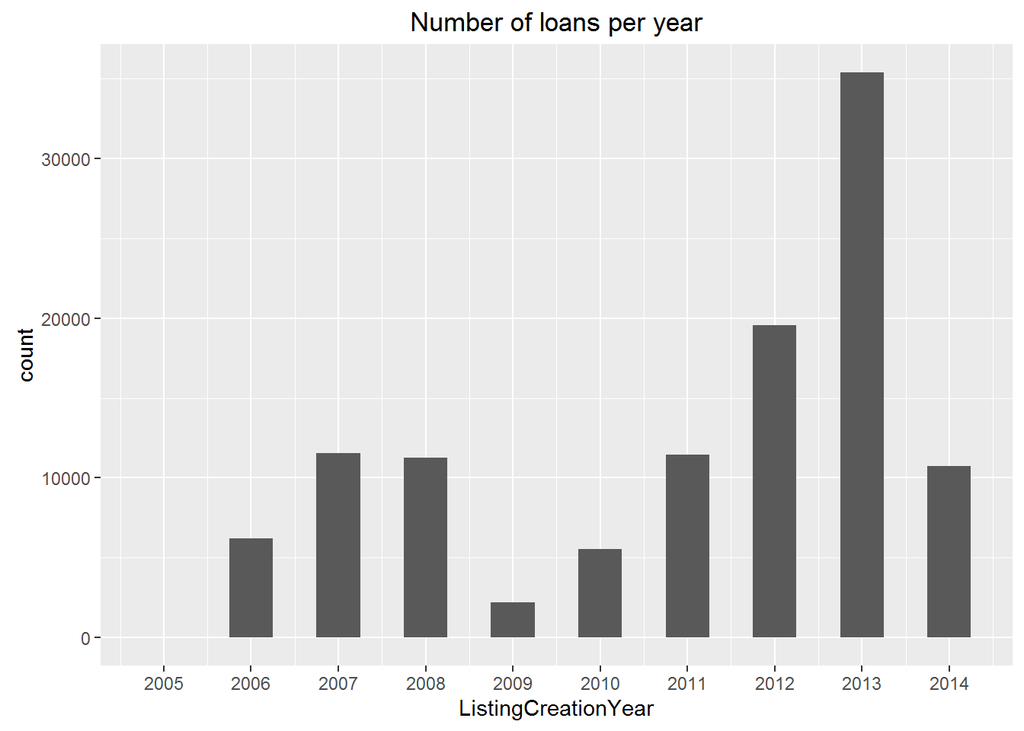

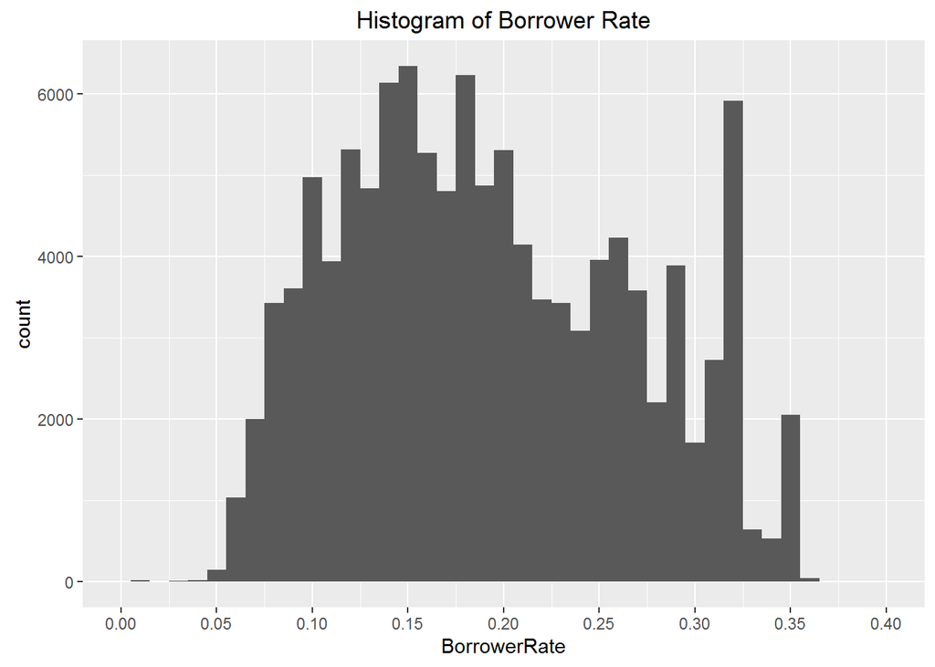

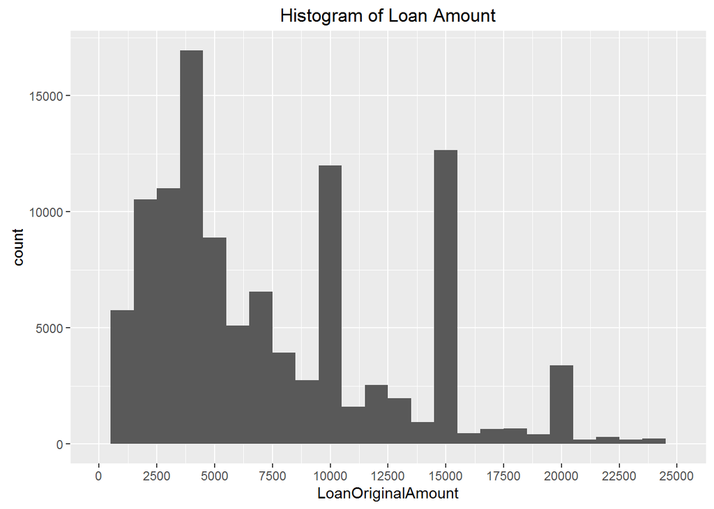

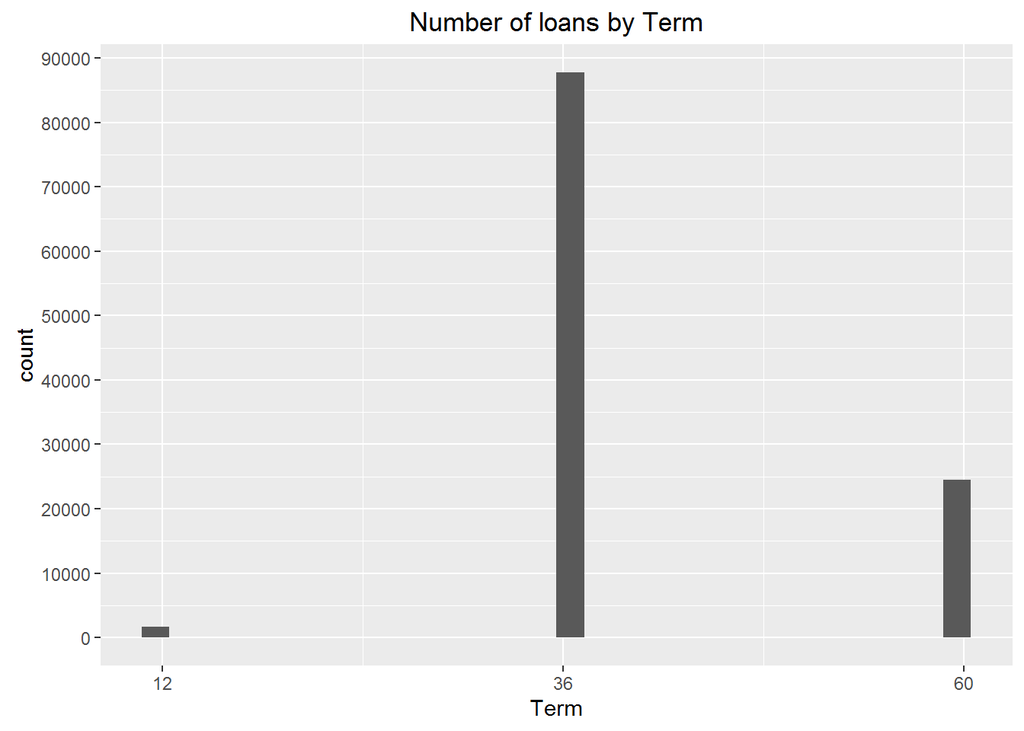

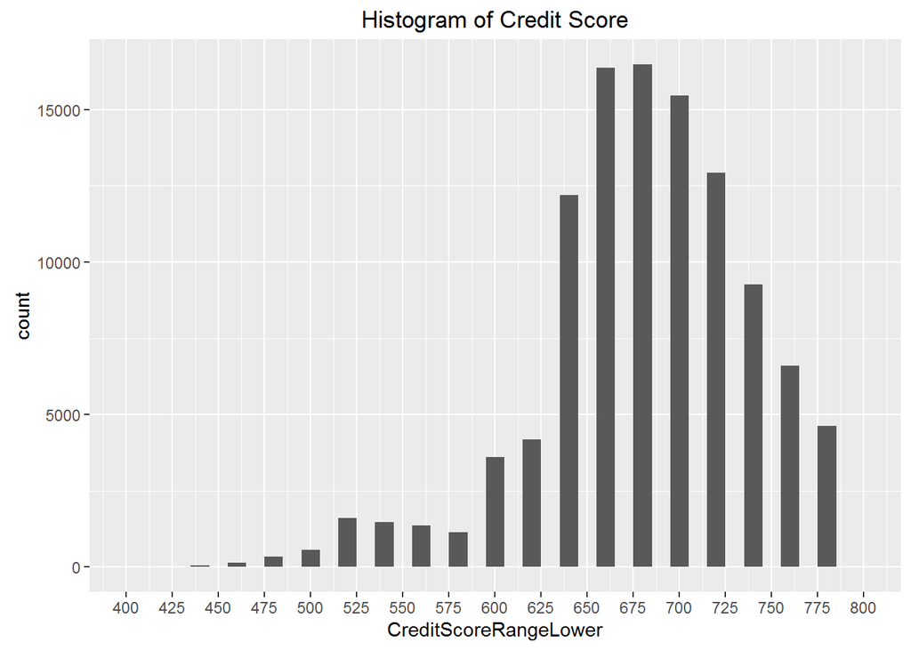

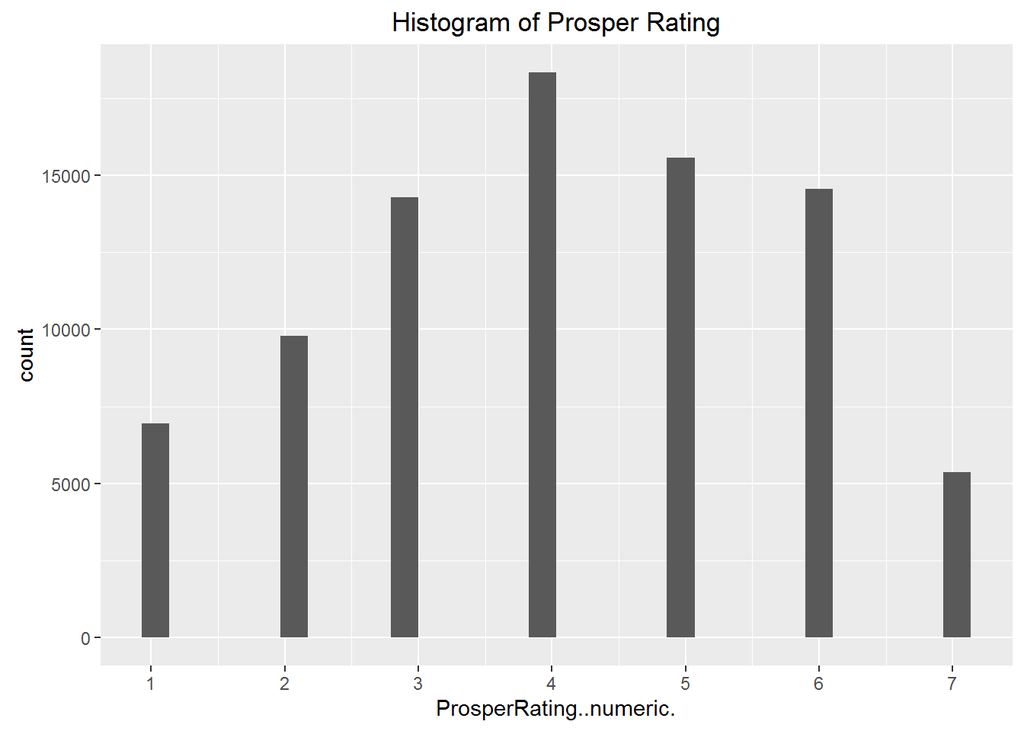

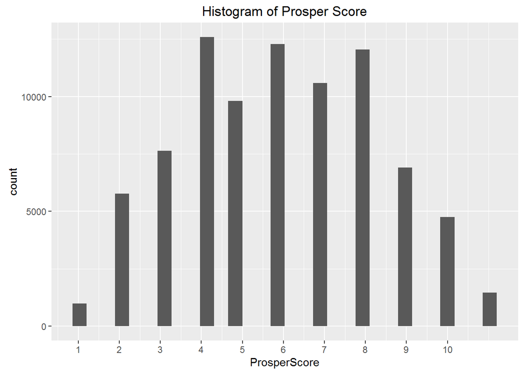

Most borrowers have a credit score around 675, which is typical in Unites States. Both Prosper Rating and Prosper Score have a normal distribution and show that most borrowers carry an average default risk.

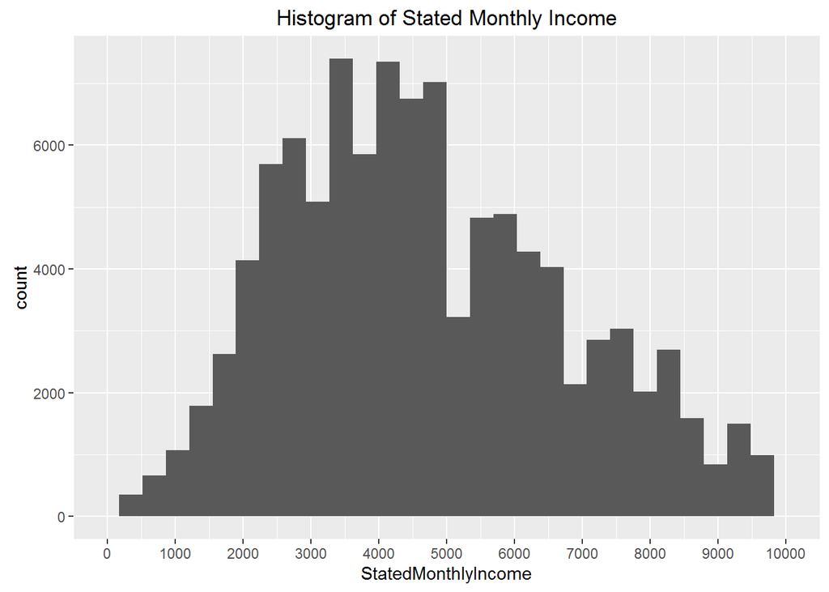

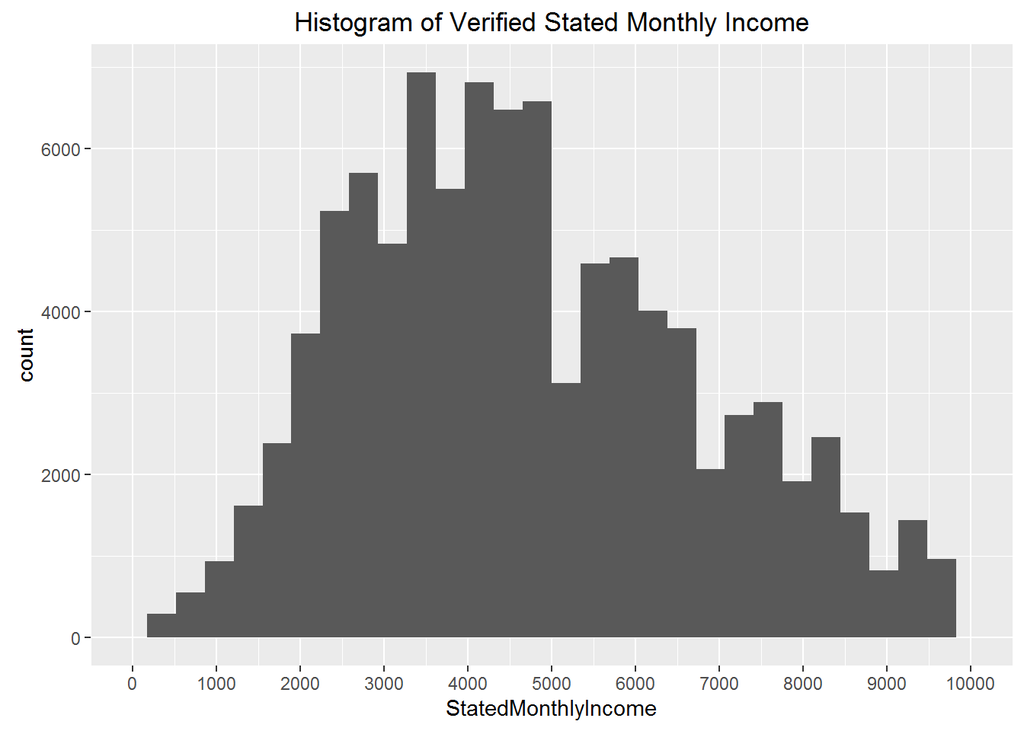

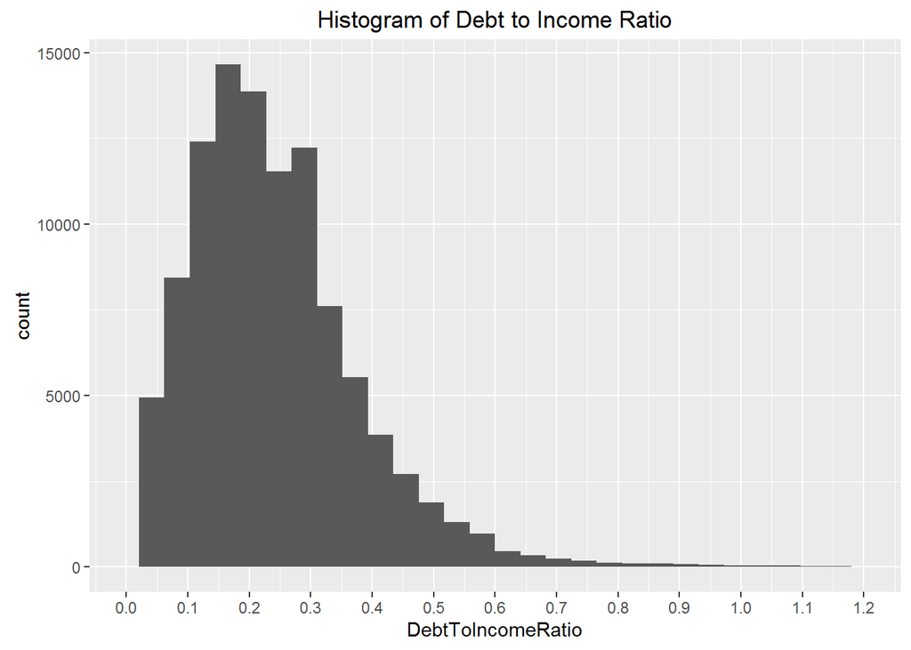

Initial histogram of stated monthly income doesn’t make much sense. It seems that the range of income is so large (from 0 to more than 600,000) that most data is crowded to the left. A quick drill-down of some extremely high earners shows that these are most likely errors. By excluding income that are more than 10,000, the histogram of stated monthly income shows a normal distribution. Most borrowers earned around $4,500 a month. Another histogram with only verified monthly income shows similar result. Debt to income ratio is largely around 20%.

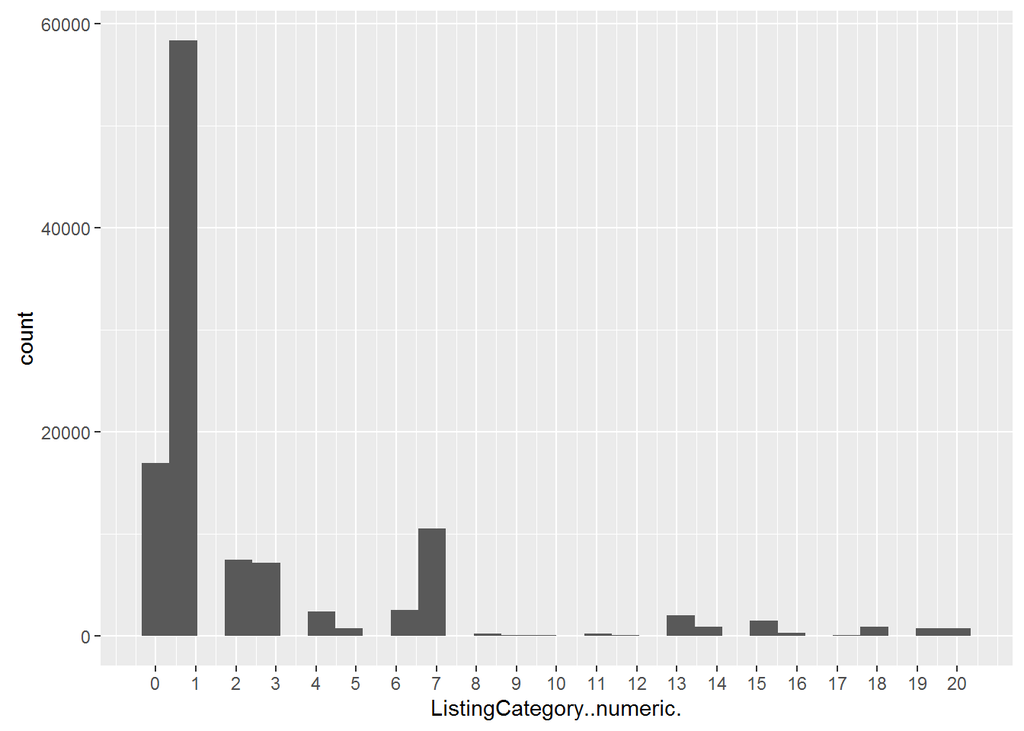

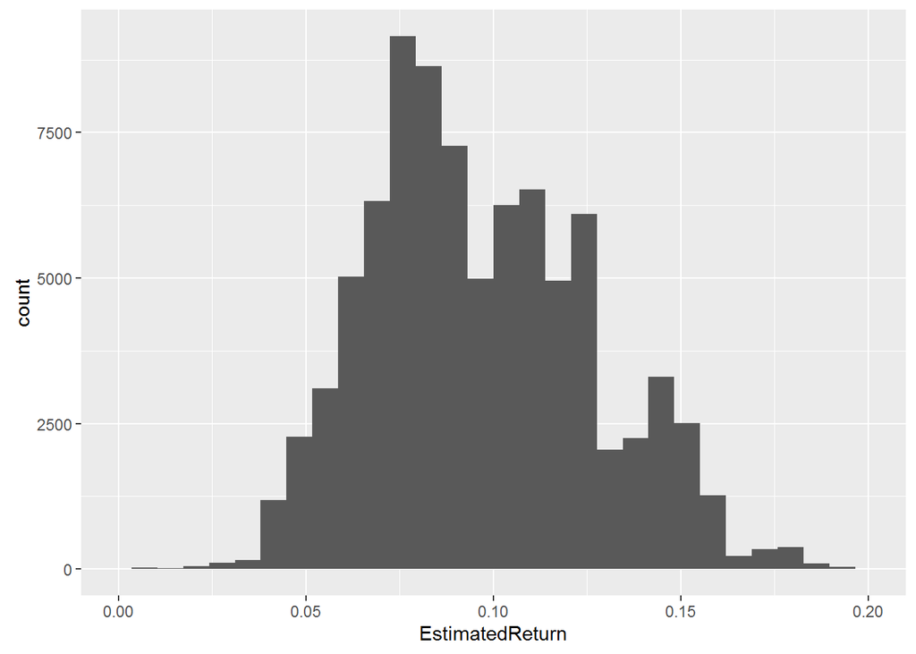

The majority of loans are for debt consolidation. The other 2 largest categories are home improvement and business. Many do not list the reason for borrowing. Overall, based on these initial graphs, the majority of Prosper borrowers seem to have good income, average credit score, and relatively low default risk (based on Prosper rating). Based on Prosper’s own metric of Estimated Return, most loans are healthy with an average 7% to 10% return.

# Univariate Analysis

### What is the structure of your dataset?

The Prosper dataset has 113937 objects with 82 variables. The variables provide information regarding the loan, the borrower, and the Prosper ratings. The data can be numeric, date, integer, range, or factors.

### What is/are the main feature(s) of interest in your dataset?

I’m interested in analyzing the real return of Prosper loans from the perspective of a lender. Prosper advertise itself as an alternative investment (rather than the traditional stocks and bonds) where lenders can help out other fellow human beings while earning a solid 7.5% estimated return on average (https://www.prosper.com/invest). Initial graphs show that borrowers have good income, healthy credit, and manageable debt ratio. Prosper’s Estimated Return supports its own claim of average 7.5% return. However, detailed analysis of completed loans (finished, charge off, or default) is needed to confirm this claim.

### What other features in the dataset do you think will help support your investigation into your feature(s) of interest?

If Prosper’s metrics do not reliably predict real return, I’d like to see if other variables (debt to income, homeowner, % of loan self-funded, etc…) would have a better correlation.

### Did you create any new variables from existing variables in the dataset?

For the graphs above, I’ve extracted the listing year from listing creation date variable. For the next portion, several new metrics regarding loan profit, return on investment will be used to examine the historical return of Prosper loans in this dataset.

### Of the features you investigated, were there any unusual distributions? Did you perform any operations on the data to tidy, adjust, or change the form of the data? If so, why did you do this?

A summary of Stated Monthly Income shows a max of 1,750,000. Close examination shows that monthly income above $10,000 are few and most likely errors. For better result, I’ve cut these outliers from the graphs. I’ve used the same approach with debt to income ratio.

# Bivariate Plots Section

To examine actual return of Prosper Loan, I’ve created a new dataset (FinishedLoan) that only contains finished loans (status is Completed, Charged Off, or Default) with Prosper Score. This creates a relatively small dataset with only 8756 objects because 1) Prosper Score is only available for loans after July 2009, 2) most loans have a 3 year term, and 3) the original dataset only goes up to March 2014. Since this is still a substantial number of loans, I’ve decided to proceed with this new dataset.

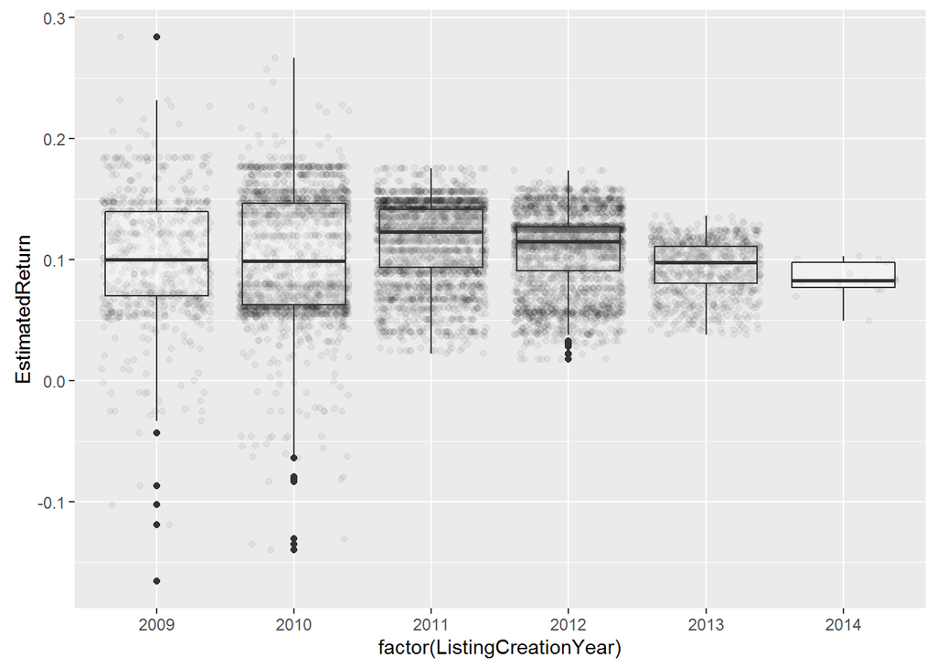

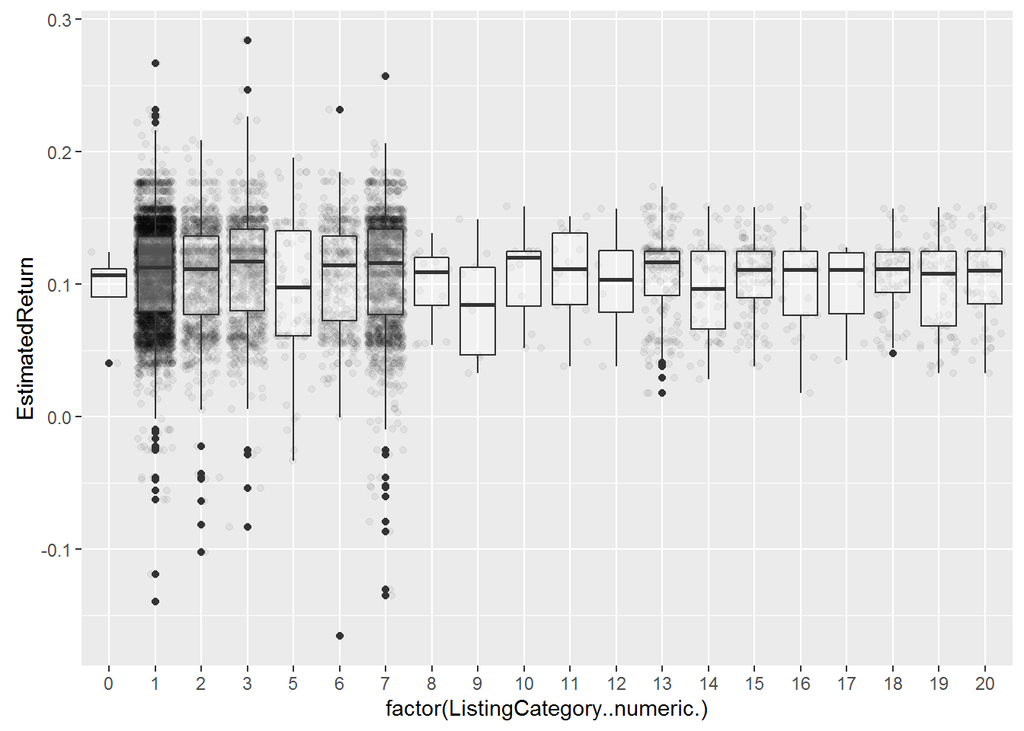

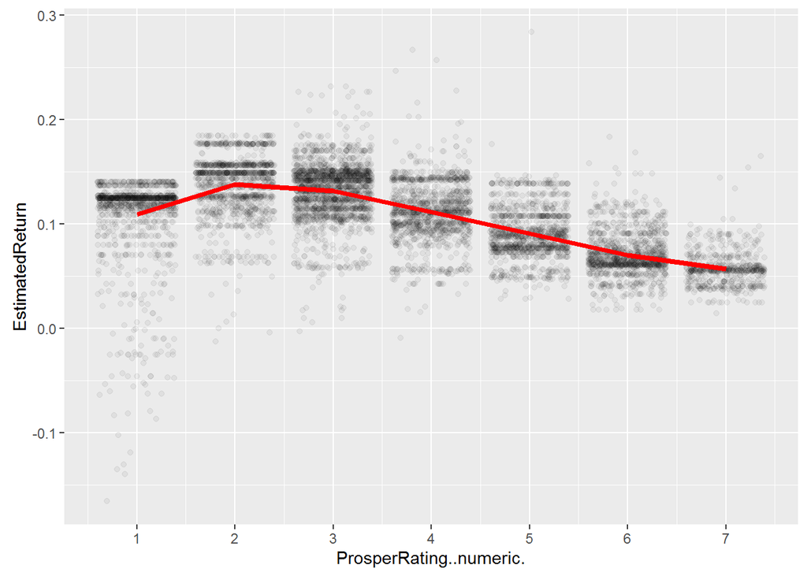

```
##
##  Pearson's product-moment correlation
##
## data:  FinishedLoan$EstimatedReturn and FinishedLoan$ProsperScore
## t = -35.699, df = 8754, p-value < 2.2e-16
## alternative hypothesis: true correlation is not equal to 0
## 95 percent confidence interval:
##  -0.3746319 -0.3380611
## sample estimates:
##        cor
## -0.3564831
```

Prosper Estimated Return is calculated by subtracting Estimated Loss from Estimated Effective Yield. Estimated Effective Yield is equal to the borrower interest rate (i) minus the servicing fee rate, (ii) minus estimated uncollected interest on charge-offs, (iii) plus estimated collected late fees. In other words, Prosper Estimated Effective Yield is the yield lender should expect on good loans that do not default. Prosper Estimated Return is the best estimate of the loan return by factoring in the default rate of similar loans.

By Prosper’s own estimation, the return on its loan seems pretty solid at around 10%. Loans with negative estimated returns are rare. Interestingly, loans with lower Prosper Score have higher estimated return compared to loans with higher score. The red trend line, which represents the mean estimated return for each Prosper Rating, rise slightly from 1 to 2, then steadily decrease as Prosper Rating gets higher. The correlation between Prosper Score and Estimated Return is -0.36. This relationship may seem reasonable since borrowers with lower credit score (or Prosper Score) are considered higher risk and must endure higher interest rate. The next few graphs continue to examine this relationship between estimated return and credit risk.

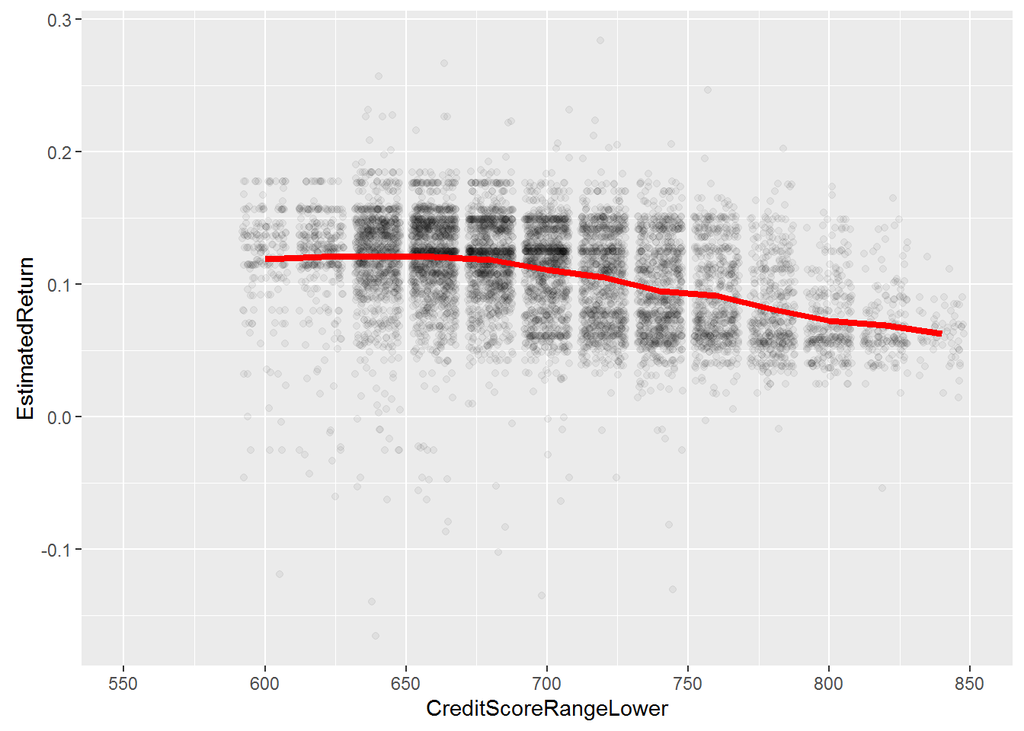

```
##
##  Pearson's product-moment correlation
##
## data:  FinishedLoan$EstimatedReturn and FinishedLoan$CreditScoreRangeLower
## t = -39.361, df = 8754, p-value < 2.2e-16
## alternative hypothesis: true correlation is not equal to 0
## 95 percent confidence interval:
##  -0.4054301 -0.3698347
## sample estimates:
##        cor
## -0.3877769
```

Similar to Prosper Score, Credit Score has a negative relationship with Estimated Return. Correlation is -0.39.

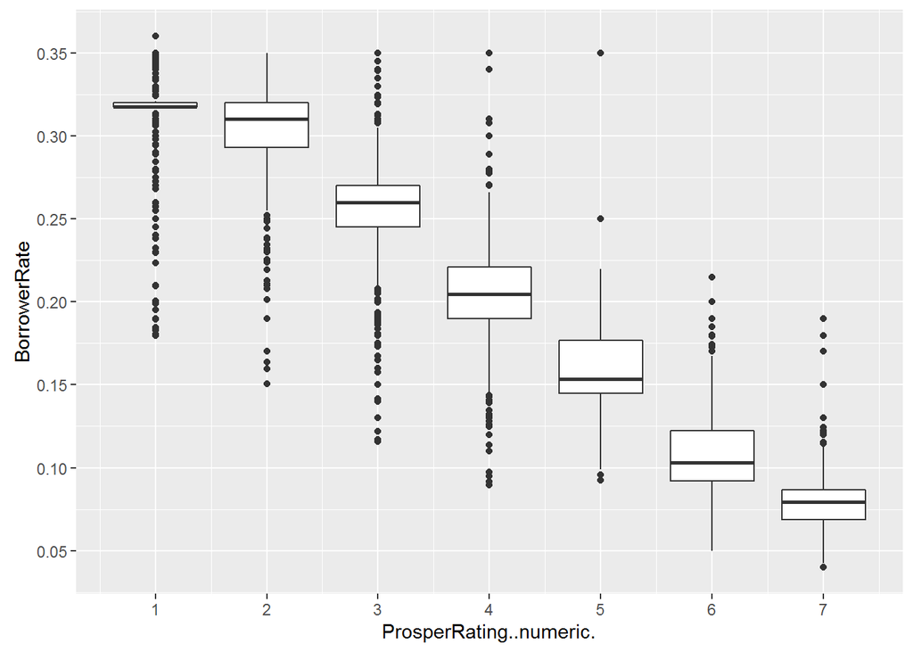

```
##
##  Pearson's product-moment correlation
##
## data:  FinishedLoan$BorrowerRate and FinishedLoan$ProsperRating..numeric.
## t = -266.27, df = 8754, p-value < 2.2e-16
## alternative hypothesis: true correlation is not equal to 0
## 95 percent confidence interval:
##  -0.9457095 -0.9411038
## sample estimates:
##        cor
## -0.9434522
```

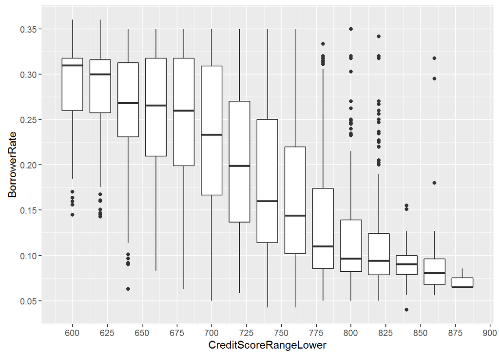

```
##
##  Pearson's product-moment correlation
##
## data:  FinishedLoan$BorrowerRate and FinishedLoan$CreditScoreRangeLower
## t = -66.066, df = 8754, p-value < 2.2e-16
## alternative hypothesis: true correlation is not equal to 0
## 95 percent confidence interval:
##  -0.5906194 -0.5626608
## sample estimates:
##       cor
## -0.576809
```

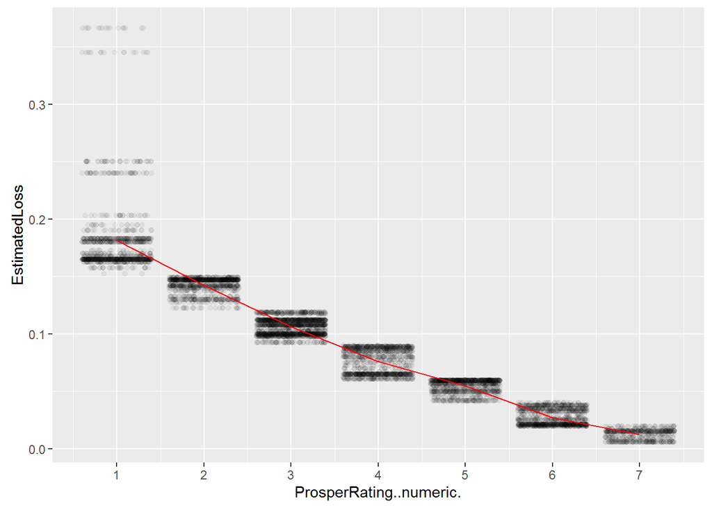

```
##
##  Pearson's product-moment correlation
##
## data:  FinishedLoan$ProsperRating..numeric. and FinishedLoan$EstimatedLoss
## t = -294.28, df = 8754, p-value < 2.2e-16
## alternative hypothesis: true correlation is not equal to 0
## 95 percent confidence interval:
##  -0.9548796 -0.9510323
## sample estimates:
##        cor
## -0.9529943
```

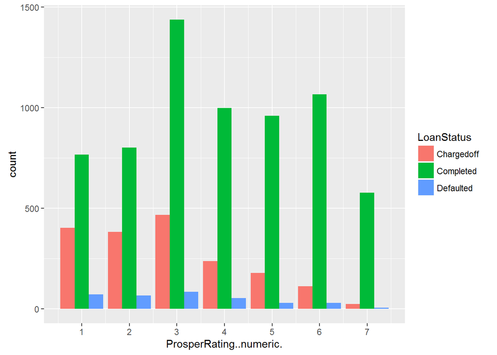

From the 2 graphs above, it can be seen that lower Prosper Rating does have higher default rate and Prosper does assign a higher loss percentage for those loans. However, these higher estimated losses do not have enough weight to significantly lower the estimated return of the whole group. If this trend holds true, lenders may be better off investing on higher risk loans (Prosper Rating = 2, 3, or 4) for higher return as long as they properly diversify to control default risk.

To test this trend and to compare Prosper’s Estimated Return with actual return, I created 3 new variables:

Loan profit or loss = (Customer Payments - Service Fees + Principle Recovery Payments - Collection Fee) - Loan Original Amount

Profit Loss Percentage = Loan profit or loss / Loan Original Amount

Profit Loss Percentage per Year = Profit Loss Percentage / (Term / 12)

```
##      Min.   1st Qu.    Median      Mean   3rd Qu.      Max.
## -23850.00     24.88    439.10   -230.60   1122.00   8902.00
```

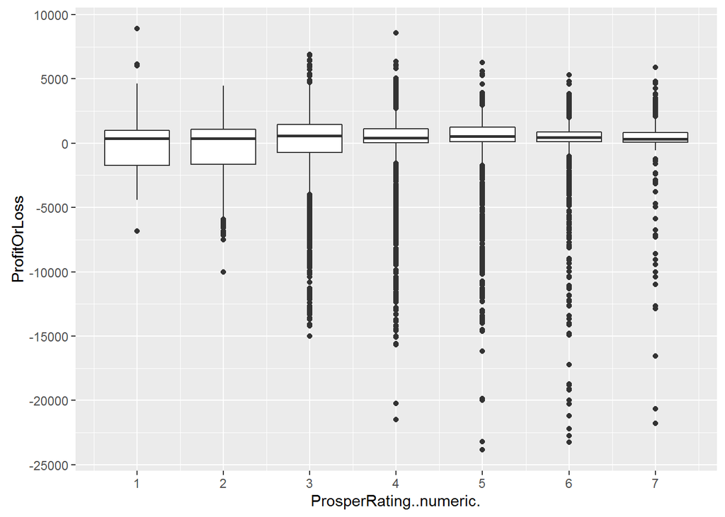

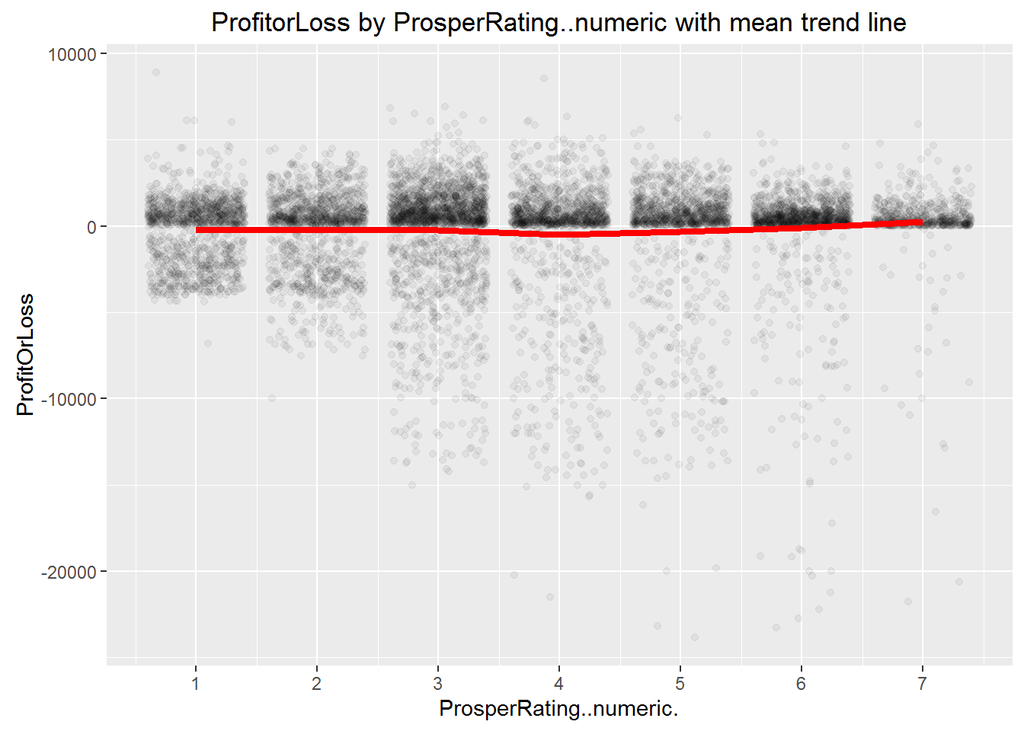

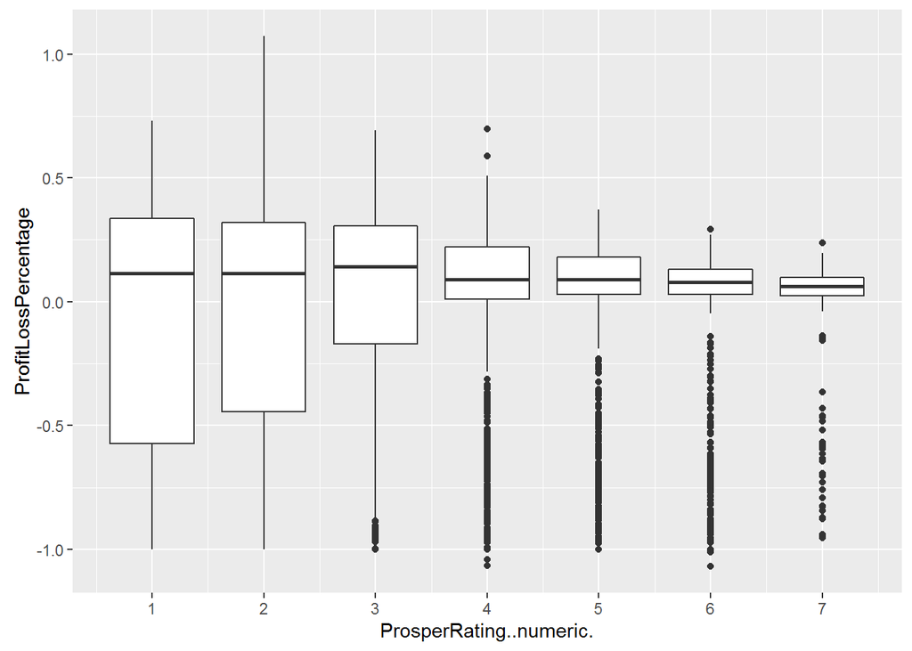

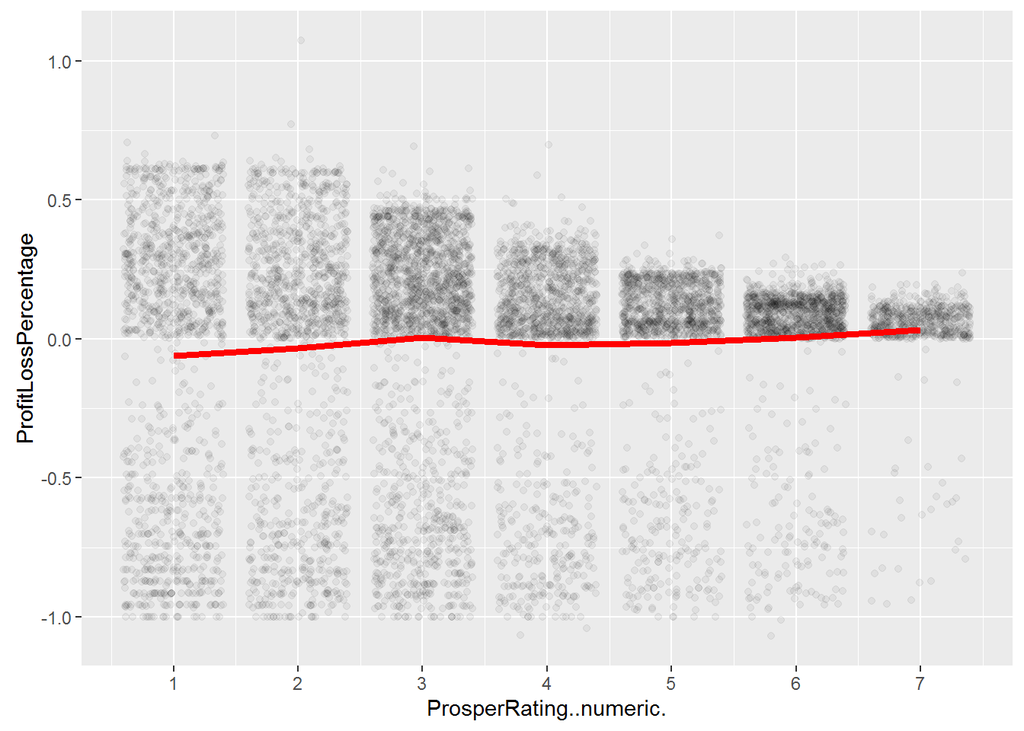

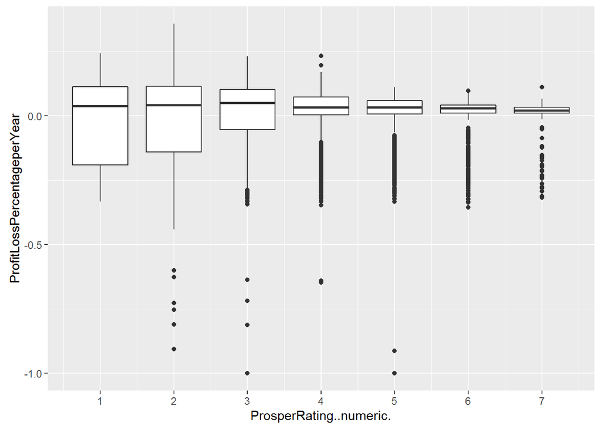

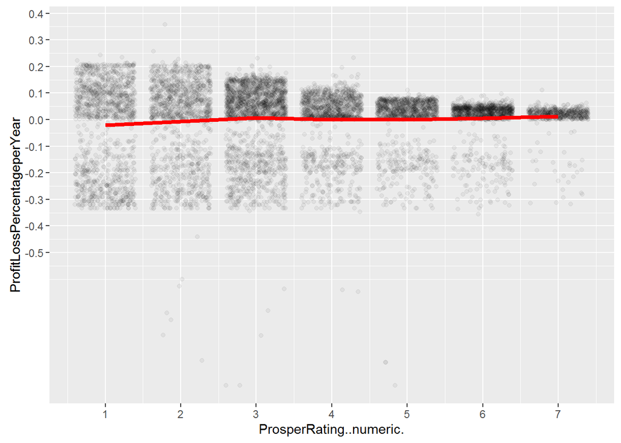

Similarly, the Profit or Loss percentage and Profit or Loss percentage per year shows low to negative mean return for most Prosper loans.

To further investigate the defaulted loans, I created a new variable to calculate the monthly payment of the annuity based on borrower rate since this data is not always available in the loan monthly payment variable. After that, I divided customer payment by the calculated monthly payment to find the estimated number of payments a borrower makes on a loan.

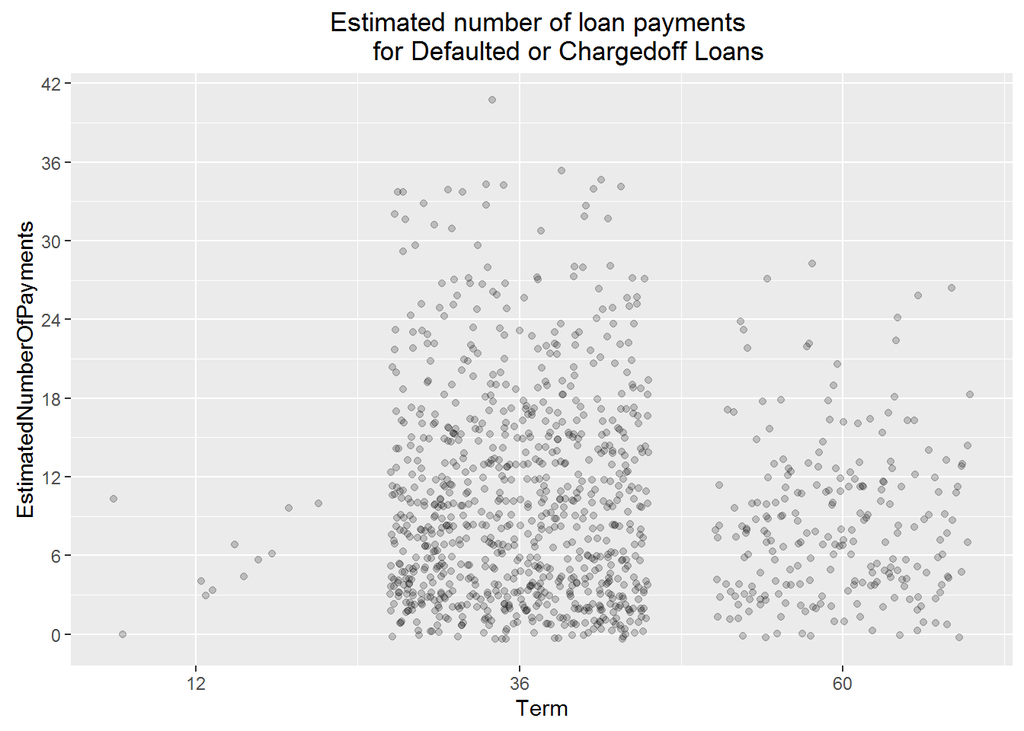

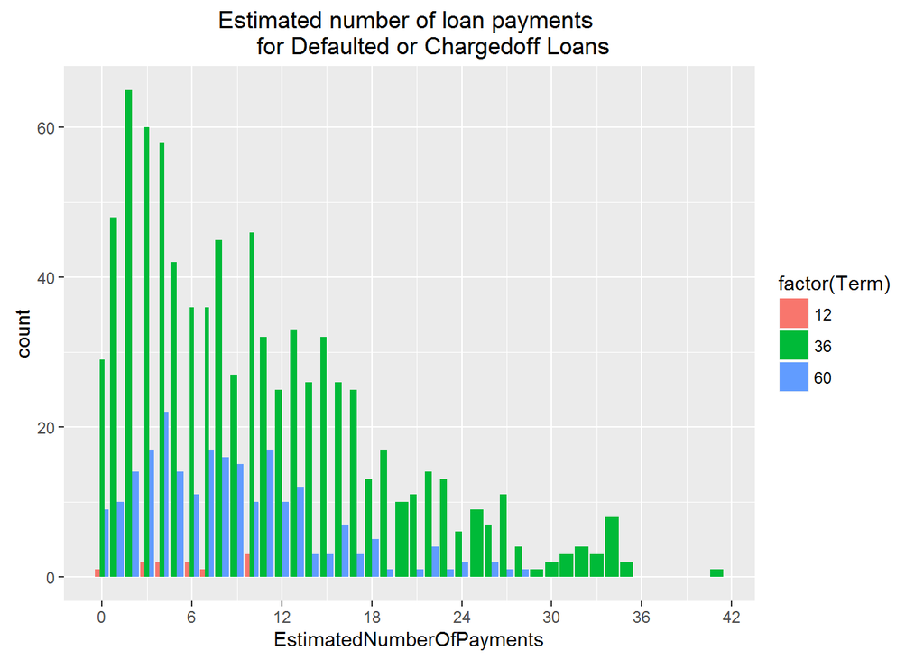

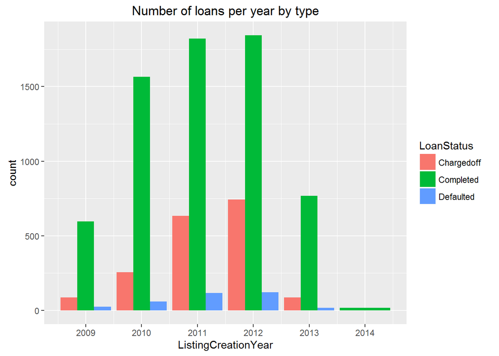

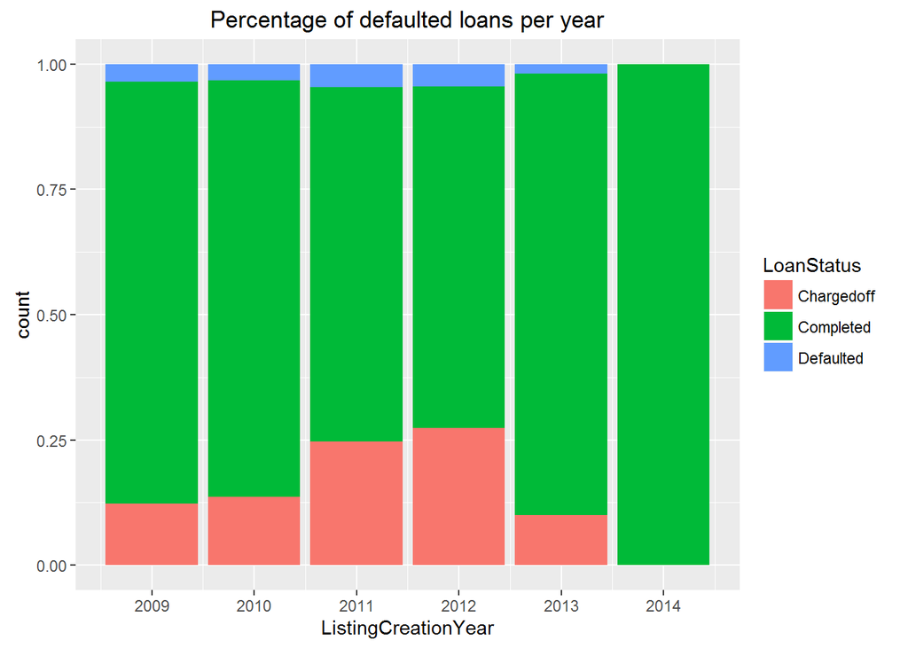

On the scatterplot, the number of loan payments for default and charge off loans are concentrated in the bottom half. This means that most borrowers default before paying off half of the loan. Similarly, the bar chart shows that most defaulted loans stop payments before reaching the halfway point of their terms. Since Prosper loans are non-collateral, lenders stand to lose all of their investments on defaulted loans. The effect of defaulted loans may explain the low profit or loss percentage that I have showed earlier. However, I do not believe Prosper would have stayed in business until now if all their lenders lost money year after year. Therefore, I’ve decided to revisit my calculations on loan return.